# Advanced usage

## Table of Contents

- 1. Introduction
- 2. Commonly Used Kernels
  - 2.1 Squared Exponential (SE)
  - 2.2 Rational Quadratic (RQ)
  - 2.3 Periodic
  - 2.4 Matern
  - 2.5 Linear
  - 2.6 Constant
  - 2.7 Noise
- 3. Combining Kernels
- 4. Custom Kernels

## 1. Introduction

In this vignette, we explore the diversity of *kernels* available in the **keRnel** package. We begin by examining commonly used kernels, then demonstrate how to combine them to address specific problems. Finally, we show how to extend the `AbstractKernel` class to create custom kernels.

```r
library(keRnel)
```

## 2. Commonly used kernels already implemented

This section provides an overview of the kernels available in the **keRnel** package. For detailed documentation, refer to:

```r
?kernel
```

| Kernel Type | Class Name | Key Parameters |
| --- | --- | --- |
| Squared Exponential | SEKernel | variance_se, length_scale_se |
| Rational Quadratic | RationalQuadraticKernel | variance_rq, length_scale_rq, alpha_rq |
| Periodic | PeriodicKernel | variance_per, length_scale_per, period |
| Matern 1/2 | MaternKernel12 | length_scale_mat |
| Matern 3/2 | MaternKernel32 | length_scale_mat |
| Matern 5/2 | MaternKernel52 | length_scale_mat |
| Linear | LinearKernel | sigma2_b, sigma2_v, c |
| Constant | ConstantKernel | value_c |
| Noise | NoiseKernel | value_c |

```r
#Input for visualization
x = matrix(rnorm(100), ncol = 2)
```

### 2.1 Squared Exponential

The **Squared Exponential (SE) kernel** is ideal for modeling **smooth functions** with infinite differentiability.

#### Definition

Let $\sigma \in \mathbb{R}_{+}$ and $\ell \in \mathbb{R}_{+}^{*}$. Consider the squared exponential kernel defined by:

$$K_{\text{SE}}(x, x') = \sigma^2 \exp\left(-\frac{\|x -
x'\|^2}{2\ell^2}\right)$$

where $\sigma$ is the signal standard deviation and $\ell$ is the length scale parameter.

```r
# Create an object of the SEKernel class.
se_kernel = new("SEKernel")
pretty_print(se_kernel)
```

```
#> [1] "SEKernel(variance=1.00, length_scale=1.00)"
```

It is possible to access both hyperparameters (${\sigma}$ and${\ell}$) and modify them.

```r
get_hyperparameter_values(se_kernel)
```

```
#>     variance_se length_scale_se
#>               1               1
```

```r
hp = c(12,1)
se_kernel = set_hyperparameters(se_kernel, hp)
pretty_print(se_kernel)
```

```
#> [1] "SEKernel(variance=12.00, length_scale=1.00)"
```

#### Visualization

One can observe the heatmap of the covariance matrix obtained using this kernel.

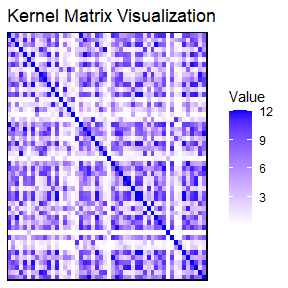

```r
visualize_kernel(se_kernel, x)
```

We can observe the relationship between the distance between the inputs and the kernel.

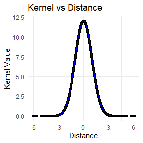

```r
plot_kernel_vs_distance(se_kernel, x)
```

### 2.2. Rational Quadratic

Let $\sigma^2 \in \mathbb{R}_{+}$, $\alpha \in \mathbb{R}_{+}^{*}$, and $\ell \in \mathbb{R}_{+}^{*}$. Consider the RQ kernel defined by:

$$K_{\text{RQ}}(x, x') = \sigma^2 \left(1 + \frac{\|x - x'\|^2}{2
\alpha \ell^2}\right)^{-\alpha}$$

```r
# Create an object of the SEKernel class.
RQ_kernel = new("RationalQuadraticKernel")
pretty_print(RQ_kernel)
```

```
#> [1] "RationalQuadraticKernel(variance=1.00, length_scale=1.00, alpha=0.10)"
```

It is possible to access both hyperparameters (${\sigma}$ and${\ell}$) and modify them.

```r
get_hyperparameter_values(RQ_kernel)
```

```
#>     variance_rq length_scale_rq        alpha_rq
#>             1.0             1.0             0.1
```

```r
hp = c(12,1,5)
RQ_kernel = set_hyperparameters(RQ_kernel, hp)
pretty_print(RQ_kernel)
```

```
#> [1] "RationalQuadraticKernel(variance=12.00, length_scale=1.00, alpha=5.00)"
```

#### Visualization

One can observe the heatmap of the covariance matrix obtained using this kernel.

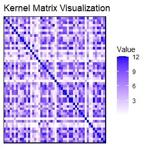

```r
visualize_kernel(RQ_kernel, x)
```

We can observe the relationship between the distance between the inputs and the kernel.

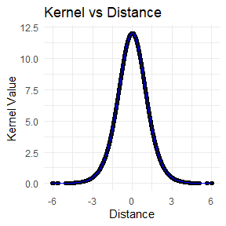

```r
plot_kernel_vs_distance(RQ_kernel, x)
```

### 2.3. Periodic Kernel

Let $\sigma^2 \in \mathbb{R}_{+}$, $\ell \in \mathbb{R}$, and $p \in \mathbb{R}$. Consider the periodic kernel defined by:

$$K_{\text{Per}}(x, x') = \sigma^2 \exp \left( -\frac{2}{\ell^2}
\sin^2 \left( \pi\frac{ x - x'}{p} \right) \right)$$

```r
# Create an object of the SEKernel class.
per_kernel = new("PeriodicKernel")
pretty_print(per_kernel)
```

```
#> [1] "PeriodicKernel(variance=1.00, length_scale=1.00, period=1.00)"
```

It is possible to access both hyperparameters (${\sigma}$ and${\ell}$) and modify them.

```r
get_hyperparameter_values(per_kernel)
```

```
#>     variance_per length_scale_per           period
#>                1                1                1
```

```r
hp = c(12,1,5)
per_kernel = set_hyperparameters(per_kernel, hp)
pretty_print(per_kernel)
```

```
#> [1] "PeriodicKernel(variance=12.00, length_scale=1.00, period=5.00)"
```

#### Visualization

One can observe the heatmap of the covariance matrix obtained using this kernel.

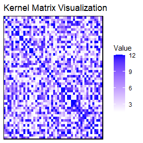

```r
visualize_kernel(per_kernel, x)
```

We can observe the relationship between the distance between the inputs and the kernel.

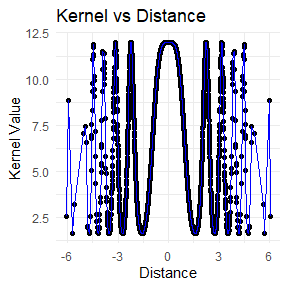

```r
plot_kernel_vs_distance(per_kernel, x)
```

### 2.4. Matern Kernel

Here we implement three common versions of the Matern kernel.

Let $\ell \in \mathbb{R}_{+}^{*}, \sigma^2 \in \mathbb{R}_{+}$. Consider the Matern Kernel with $\nu$ =1/2 defined by:

$$K_{\text{Mat}_{\nu = \frac{1}{2}}}(x, x') = \sigma^2\cdot
exp\left(-\frac{\|x - x'\|^2}{\ell}\right)$$

```r
# Create an object of the SEKernel class.
mat_kernel12 = new("MaternKernel12")
pretty_print(mat_kernel12)
```

```
#> [1] "MaternKernel12(length_scale=1.00)"
```

```r
get_hyperparameter_values(mat_kernel12)
```

```
#> length_scale_mat
#>                1
```

```r
hp = c(12)
mat_kernel12 = set_hyperparameters(mat_kernel12, hp)
pretty_print(mat_kernel12)
```

```
#> [1] "MaternKernel12(length_scale=12.00)"
```

#### Visualization

One can observe the heatmap of the covariance matrix obtained using this kernel.

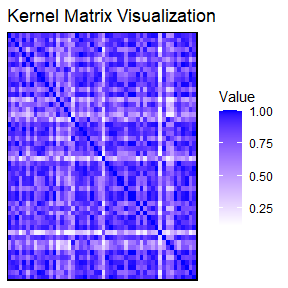

```r
visualize_kernel(mat_kernel12, x)
```

We can observe the relationship between the distance between the inputs and the kernel.

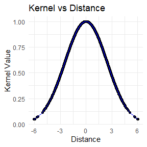

```r
plot_kernel_vs_distance(mat_kernel12, x)
```

Let $\ell \in \mathbb{R}_{+}^{*}$, $\sigma^2 \in \mathbb{R}_{+}$. Consider the Matern Kernel with $\nu$ =3/2 defined by:

$$K_{\text{Mat}_{\nu = \frac{3}{2}}}(x, x') = \sigma^2\cdot\left(
\frac{\sqrt{3}\cdot\|x - x'\|^2}{\ell}
+1\right)exp\left(-\frac{\sqrt{3}\cdot\|x - x'\|^2}{\ell}\right)$$

```r
# Create an object of the SEKernel class.
mat_kernel32 = new("MaternKernel32")
pretty_print(mat_kernel32)
```

```
#> [1] "MaternKernel32(length_scale=1.00)"
```

```r
get_hyperparameter_values(mat_kernel32)
```

```
#> length_scale_mat
#>                1
```

```r
hp = c(12)
mat_kernel32 = set_hyperparameters(mat_kernel32, hp)
pretty_print(mat_kernel32)
```

```
#> [1] "MaternKernel32(length_scale=12.00)"
```

#### Visualization

One can observe the heatmap of the covariance matrix obtained using this kernel.

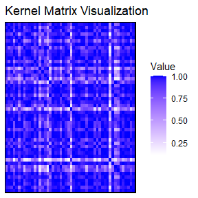

```r
visualize_kernel(mat_kernel32, x)
```

We can observe the relationship between the distance between the inputs and the kernel.

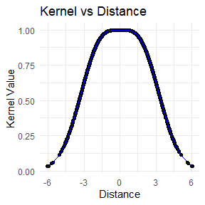

```r
plot_kernel_vs_distance(mat_kernel32, x)
```

Let $\ell \in \mathbb{R}_{+}^{*}$, $\sigma^2 \in \mathbb{R}_{+}$. Consider the Matern Kernel with $\nu$ =5/2 defined by:

$$K_{\text{Mat}_{\nu = \frac{5}{2}}}(x, x') = \sigma^2\cdot\left(
\left( \frac{5(\|x - x'\|^2)^2}{3\ell^2} + \frac{\sqrt{5}\|x -
x'\|^2}{\ell} + 1 \right) \exp \left( -\frac{\sqrt{5}\|x -
x'\|^2}{\ell} \right) \right)$$

```r
# Create an object of the SEKernel class.
mat_kernel52 = new("MaternKernel52")
pretty_print(mat_kernel52)
```

```
#> [1] "MaternKernel52(length_scale=1.00)"
```

```r
get_hyperparameter_values(mat_kernel52)
```

```
#> length_scale_mat
#>                1
```

```r
hp = c(12)
mat_kernel52 = set_hyperparameters(mat_kernel52, hp)
pretty_print(mat_kernel52)
```

```
#> [1] "MaternKernel52(length_scale=12.00)"
```

#### Visualization

One can observe the heatmap of the covariance matrix obtained using this kernel.

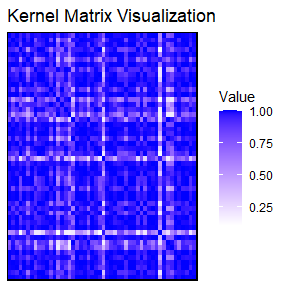

```r
visualize_kernel(mat_kernel52, x)
```

We can observe the relationship between the distance between the inputs and the kernel.

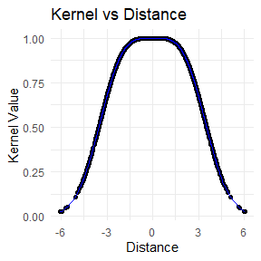

```r
plot_kernel_vs_distance(mat_kernel52, x)
```

### 2.5. Linear Kernel

**Linear Kernel** is used for linear relationships (e.g., polynomial regression, feature interactions).

#### Definition

Let $\sigma^2_b \in \mathbb{R}_{+}$, $\sigma^2_v \in \mathbb{R}_{+}$, and $c \in \mathbb{R}$. Consider the linear kernel defined by:

$$K_{\text{Lin}}(x, x') = \sigma^2_b + \sigma^2_v (x - c)(x' - c)$$

```r
# Create an object of the SEKernel class.
lin_kernel = new("LinearKernel")
pretty_print(lin_kernel)
```

```
#> [1] "LinearKernel(sigma2_b=1.00, sigma2_v=1.00, c=1.00)"
```

```r
get_hyperparameter_values(lin_kernel)
```

```
#> sigma2_b sigma2_v        c
#>        1        1        1
```

```r
hp = c(12,1,5)
lin_kernel = set_hyperparameters(lin_kernel, hp)
pretty_print(lin_kernel)
```

```
#> [1] "LinearKernel(sigma2_b=12.00, sigma2_v=1.00, c=5.00)"
```

#### Visualization

One can observe the heatmap of the covariance matrix obtained using this kernel.

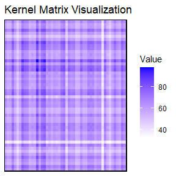

```r
visualize_kernel(lin_kernel, x)
```

We can observe the relationship between the distance between the inputs and the kernel.

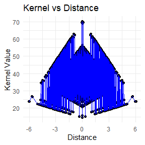

```r
plot_kernel_vs_distance(lin_kernel, x)
```

### 2.6. Constant Kernel

**Constant Kernel** adds,for instance, a global bias.

#### Definition

Let $c \in \mathbb{R}_{+}^{*}$. Consider the constant kernel defined by:

$$K_{\text{cst}}(x, x') = c \cdot \begin{bmatrix}
1 & 1 & \cdots & 1 \\
1 & 1 & \cdots & 1 \\
\vdots & \vdots & \ddots & \vdots \\
1 & 1 & \cdots & 1
\end{bmatrix}$$

```r
# Create an object of the SEKernel class.
cst_kernel = new("ConstantKernel")
pretty_print(cst_kernel)
```

```
#> [1] "ConstantKernel(1.00)"
```

```r
get_hyperparameter_values(cst_kernel)
```

```
#> value_c
#>       1
```

```r
hp = c(12)
cst_kernel = set_hyperparameters(cst_kernel, hp)
pretty_print(cst_kernel)
```

```
#> [1] "ConstantKernel(12.00)"
```

#### Visualization

One can observe the heatmap of the covariance matrix obtained using this kernel.

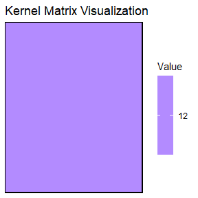

```r
visualize_kernel(cst_kernel, x)
```

We can observe the relationship between the distance between the inputs and the kernel.

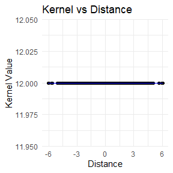

```r
plot_kernel_vs_distance(cst_kernel, x)
```

### 2.7. Noise Kernel

Let $c \in \mathbb{R}_{+}^{*}$. Consider the noise kernel defined by:

$$K_{\text{noise}}(x, x') = c \cdot I_n$$

```r
# Create an object of the SEKernel class.
noise_kernel = new("NoiseKernel")
pretty_print(noise_kernel)
```

```
#> [1] "NoiseKernel(1.00)"
```

```r
get_hyperparameter_values(noise_kernel)
```

```
#> value_c
#>       1
```

```r
hp = c(12)
noise_kernel = set_hyperparameters(noise_kernel, hp)
pretty_print(noise_kernel)
```

```
#> [1] "NoiseKernel(12.00)"
```

#### Visualization

One can observe the heatmap of the covariance matrix obtained using this kernel.

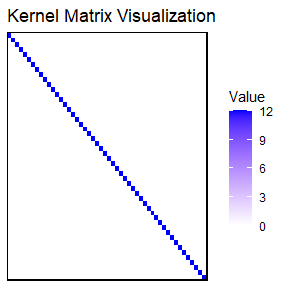

```r
visualize_kernel(noise_kernel, x)
```

We can observe the relationship between the distance between the inputs and the kernel.

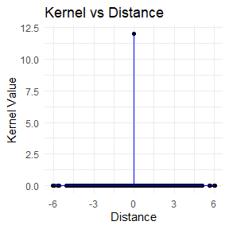

```r
plot_kernel_vs_distance(noise_kernel, x)
```

For detailed documentation, use:

```r
# Access the documentation for a specific kernel
?SEKernel
?RationalQuadraticKernel
# Or browse all available kernels
help(package = "keRnel")
```

## 3. Sum and product of kernels

We can exploit the properties that stipulate that a sum of kernels remains a kernel and that the product of kernels remains a kernel to construct more complex kernels.

The class system greatly simplifies this part. Objects created by sum or product are elements of the **SumKernel** or **ProductKernel** class, which inherits from **AbstractKernel** like the usual kernels. This means you can access the same title with hyperparameters and use the visualization functions.

```r
linear_k = new("LinearKernel",sigma2_b = 1, sigma2_v = 1, c = 0)
noise_k = new("NoiseKernel",value_c = 0.1)

combined_k = linear_k + noise_k

pretty_print(combined_k)
```

```
#> [1] "[LinearKernel(sigma2_b=1.00, sigma2_v=1.00, c=0.00) + NoiseKernel(0.10)]"
```

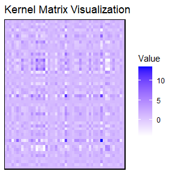

```r
visualize_kernel(combined_k, x)
```

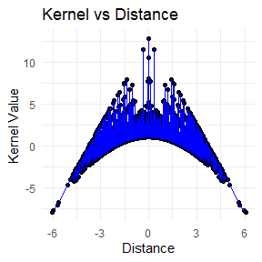

```r
plot_kernel_vs_distance(combined_k, x)
```

### Kernel spatio-temporal

```r
se_space_k = new("SEKernel",variance_se = 1, length_scale_se = 1)  # Space
periodic_time_k = new("PeriodicKernel",variance_per = 1, length_scale_per = 0.5, period = 1)  # Time

combined_k  = se_space_k * periodic_time_k

pretty_print(combined_k)
```

```
#> [1] "[SEKernel(variance=1.00, length_scale=1.00) * PeriodicKernel(variance=1.00, length_scale=0.50, period=1.00)]"
```

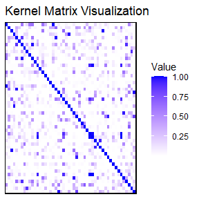

```r
visualize_kernel(combined_k, x)
```

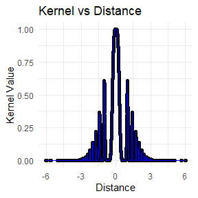

```r
plot_kernel_vs_distance(combined_k, x)
```

## 4. Custom Kernels

You can extend the AbstractKernel class to implement custom kernels. Here is a minimal example with a kernel based on Minkowski distance :

```r
# Define a custom kernel class
setClass(
  "MinkowskiKernel",
  contains = "AbstractKernel",
  slots = c(
    p = "numeric",    # Minkowski distance shape parameter
    sigma = "numeric" # lengthscale
  )
)

# Define the pairwise kernel method
setMethod(
  "pairwise_kernel", "MinkowskiKernel",
  function(obj, x, y) {
    dx = outer(rowSums(x^2), rowSums(y^2), FUN = "+") - 2 * tcrossprod(x, y)
    exp(- dx^obj@p/ obj@sigma)

  }
)

# Define the hyperparameters method
setMethod(
  "gt_HPs", "MinkowskiKernel",
  function(obj) {
    list(sigma = obj@sigma, p = obj@p)
  }
)

# Define the pretty print method
setMethod(
  "pretty_print", "MinkowskiKernel",
  function(obj) {
    sprintf("MinkowskiKernel(p=%.2f, sigma=%.2f)", obj@p, obj@sigma)
  }
)

# Créer une instance du noyau
minkowski_kernel = new("MinkowskiKernel", p = 2, sigma = 1.0)
pretty_print(minkowski_kernel)
```

```
#> [1] "MinkowskiKernel(p=2.00, sigma=1.00)"
```

```r
# Compute the kernel matrix
K_custom = pairwise_kernel(minkowski_kernel, x, x)

print(K_custom[12,3])
```

```
#> [1] 0.1644258
```

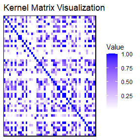

```r
visualize_kernel(minkowski_kernel, x)
```

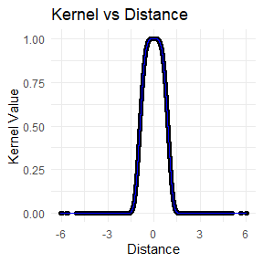

```r
plot_kernel_vs_distance(minkowski_kernel, x)
```